# List

*CSCI 1913 – Introduction to Algorithms, Data Structures, and Program Development*  
Adriana Picoral

## List

An ordered, finite, mutable data structure

- Plan out, in the abstract, the “object nature” and what behaviors you need to support
- Write some example/test code

## List

- What is a list?
- How do we use lists?
- What methods do we need?

## List

- An ordered, finite, mutable data structure
- We manipulate it (create list, add, append, remove, insert, get length, set an individual value)
- append, prepend, insert, length, set, search

What about sort?

## List methods

How do we do lists?

create list of a specific size, append, prepend, remove, insert, getLength, search, sort

## List interface

Let’s implement a list interface.

- Remember that an interface only contains method signatures.

Let’s start with the basic methods:

## List interface

Here’s our initial generic interface:

```java
public interface List<T> {
    void append(T value);
    int length();
    T get(int index);
    void set(int index, T value);
}
```

## List Implementation

- Data structures, or abstract data types (ADTs) can be implemented using different approaches
- We have our `List` interface, we will start by implementing our `List` with an array
- We will call our class `ArrayList` and we will use the `implements` keyword:

```java
public class ArrayList<T> implements List<T> {}
```

## ArrayList

Here’s how we are setting up the private instance variable: `private T[] data;`

Constructor:

```java
public ArrayList() {
  data = (T[]) new Object[size]; // define an arbitraty size
}
```

## ArrayList

We will create a generic `ArrayList` that implements `List`

```java
public class ArrayList<T> implements List<T> {
    private T[] data;
    private int size = 10;
    private int length  = 0;


    @SuppressWarnings("unchecked")
    public ArrayList() {
        data = (T[]) new Object[size];
    }

    @Override
    public int length() {
        return length;
    }

    @Override
    public void append(T value) {
      // TODO: implement
    }

    @Override
    public T get(int index) {
        // TODO: implement
    }

    @Override
    public void set(int index, T value) {
        // TODO: implement
    }


}
```

## Finish implementation

Submit your `List.java` and `ArrayList.java` files to [gradescope](https://www.gradescope.com/courses/1233898/assignments/7897949/).

```java
public class UseList {
    public static void main(String[] args) {
        List<String> fruitList = new ArrayList<>();
        System.out.println(fruitList.length()); // 0
        System.out.println(fruitList);

        fruitList.append("apple");
        fruitList.append("pear");
        fruitList.append("banana");

        System.out.println(fruitList);
    }
}
```

## ArrayList append

```java
@Override
public void append(T value) {
  data[length] = value;
  length++;
}
```

What happens when length is the same as size?

## Expand the size of our array

```java
@SuppressWarnings("unchecked")
private void expandArray() {
  size *= 2;
  T[] newData = (T[]) new Object[size];
  for (int i = 0; i < length; i++) newData[i] = data[i];
  data = newData;
}
```

## append implementation

```java
@Override
public void append(T value) {
  if (length == size) expandArray();
  data[length] = value;
  length++;
}
```

## Submit to gradescope with array Expand

Submit your `List.java` and `ArrayList.java` files to [gradescope](https://www.gradescope.com/courses/1233898/assignments/7898743/) making sure your array implementation can do multiple append calls (your implementation deals with array expansion)

## Runtime of array Expand

The `arrayExpand` process is $O(n)$ (gotta copy the array!) BUT it doesn’t run every time, so how do we handle the aﬀect on append?

Best case: $O(1)$ Worst case: $O(n)$

## Runtime of array Expand

What we often care about is not the runtime of `myList.append(4);` but instead:

```java
for (int i = 0; i < N; i++) {
  myList.append(i);
}
```

## Runtime of array Expand

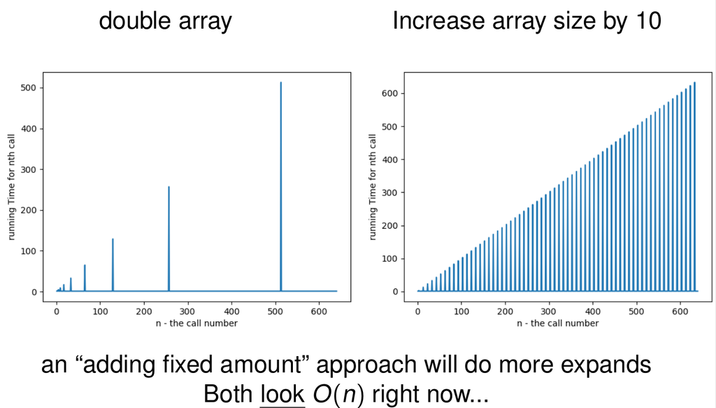

double array vs. increase array size by 10 plots